# Accessing Genome Data

reading a vcf file:

```
/home/lagrange2/Desktop/PI4 2017
```

```r
library(vcfR)
genome_table <- read.vcfR('imp_TERRA_RIL_SNP.vcf')
```

[output not shown]

accessing the fix, meta, and gt files:

This gives the data for the reference DNA and puts it into a fll table: be careful with accessing the gt file since it is so large

```r
reference = genome_table@fix
View(reference)
gt_file = genome_table@gt
meta_file = genome_table@meta
```

The meta file gives you the meta data of the file:

```r
meta_file = genome_table@meta
meta_file
```

```
[1] "##fileformat=VCFv4.2"
[2] "##filedate=20161128"
[3] "##source=\"beagle.22Feb16.8ef.jar (version 4.1)\""
[4] "##INFO=<ID=AF,Number=A,Type=Float,Description=\"Estimated Allele Frequencies\">"
[5] "##INFO=<ID=AR2,Number=1,Type=Float,Description=\"Allelic R-Squared: estimated squared correlation between most probable REF dose and true REF dose\">"
[6] "##INFO=<ID=DR2,Number=1,Type=Float,Description=\"Dosage R-Squared: estimated squared correlation between estimated REF dose [P(RA) + 2*P(RR)] and true REF dose\">"
[7] "##FORMAT=<ID=GT,Number=1,Type=String,Description=\"Genotype\">"
[8] "##FORMAT=<ID=DS,Number=1,Type=Float,Description=\"estimated ALT dose [P(RA) + P(AA)]\">"
[9] "##FORMAT=<ID=GP,Number=G,Type=Float,Description=\"Estimated Genotype Probability\">"
```

To access a single genome (there are 304), access a column of the gt file (genome data starts at column 2). The genome is presented in the a|b format, where $a,b \in \{ 0,1 \}$. The way to read this is comparing to the reference. The reference gives you the column of reference or dominant alleles, but also a table of the alternate. a sequence with 0|0 means that the entry has the dominant on both sides of the Helix, 0|1 and 1|0 means a dominant on one side, alternate on the other, and 1|1 means alterante alleles on both sides. To get the genome keys, simply take the 0th row. This gives you the “format” key, the rest of the keys, and then the “reference genome”. You can also access genomes with specific keys:

```r
table1 = gt_file[,2] #access a single genome, pick numbers between 2 and 305
key_names = gt_file[0,] # access the names of the file as a matrix
attr(gt_file,"dimnames") # access the names of files as a list of character strings
```

```
[[1]]
NULL

[[2]]
  [1] "FORMAT"                  "X11CS2572.2571.MERGE"    "X12CS2536.MERGE"         "X13CS1808.MERGE"
  [5] "X13CS21123.MERGE"        "X13CS21127.MERGE"        "X13CS2134.MERGE"         "X13CS221.MERGE"
  [9] "X13CS3592.MERGE"         "X14CS2180.2179.MERGE"    "X14CS2360.2359.MERGE"    "X14CS3450.3377.MERGE"
 [13] "X14CS3450.3389.MERGE"    "X14CS3450.3441.MERGE"    "X14CS3450.3445.MERGE"    "X14CS3450.3449.MERGE"
 [17] "X15CS1912.1911.MERGE"    "X15CS3315.MERGE"         "X15FS279_NSZ.MERGE"      "X15FS280_NSZ.MERGE"
 [21] "X15FS281_NSZ.MERGE"      "X15FS282_NSZ.MERGE"      "X15FS283_NSZ.MERGE"      "X15FS284_NSZ.MERGE"
 [25] "X15FS285_NSZ.MERGE"      "X15FS286_NSZ.MERGE"      "X15FS287_NSZ.MERGE"      "X15FS288_NSZ.MERGE"
 [29] "X15FS289_NSZ.MERGE"      "X15FS290_NSZ.MERGE"      "X15FS291_NSZ.MERGE"      "X15FS292_NSZ.MERGE"
 [33] "X15FS293_NSZ.MERGE"      "X15FS294_NSZ.MERGE"      "X15FS295_NSZ.MERGE"      "X15FS296_BTx623_P.MERGE"
 [37] "X15FS297_NSZ_P.MERGE"    "X15FS515_NSZ.MERGE"      "X15WF2049.1.MERGE"       "X15WF2088.1.MERGE"
 [41] "X15WF2095.1.MERGE"       "X15WF2101.1.MERGE"       "X15WF2263.1.MERGE"       "X16PR1252.MERGE"
```

[output cut: 66 more lines]

```r
PI_tables=gt_file[,startsWith(colnames(gt_file),"PI")] # creates a table of genomes whose IDs begin with PI
key_names
```

```
     FORMAT X11CS2572.2571.MERGE X12CS2536.MERGE X13CS1808.MERGE X13CS21123.MERGE X13CS21127.MERGE X13CS2134.MERGE X13CS221.MERGE
     X13CS3592.MERGE X14CS2180.2179.MERGE X14CS2360.2359.MERGE X14CS3450.3377.MERGE X14CS3450.3389.MERGE X14CS3450.3441.MERGE
     X14CS3450.3445.MERGE X14CS3450.3449.MERGE X15CS1912.1911.MERGE X15CS3315.MERGE X15FS279_NSZ.MERGE X15FS280_NSZ.MERGE
     X15FS281_NSZ.MERGE X15FS282_NSZ.MERGE X15FS283_NSZ.MERGE X15FS284_NSZ.MERGE X15FS285_NSZ.MERGE X15FS286_NSZ.MERGE
     X15FS287_NSZ.MERGE X15FS288_NSZ.MERGE X15FS289_NSZ.MERGE X15FS290_NSZ.MERGE X15FS291_NSZ.MERGE X15FS292_NSZ.MERGE
     X15FS293_NSZ.MERGE X15FS294_NSZ.MERGE X15FS295_NSZ.MERGE X15FS296_BTx623_P.MERGE X15FS297_NSZ_P.MERGE X15FS515_NSZ.MERGE
     X15WF2049.1.MERGE X15WF2088.1.MERGE X15WF2095.1.MERGE X15WF2101.1.MERGE X15WF2263.1.MERGE X16PR1252.MERGE X16PR1253.MERGE
     X16PR1254.MERGE X16PR1255.MERGE X16PR1256.MERGE X16PR1257.MERGE X16PR1258.MERGE X16PR1259.MERGE X16PR1260.MERGE
     X16PR1261.MERGE X16PR1262.MERGE X16PR1263.MERGE X16PR1264.MERGE X16PR1265.MERGE X16PR1266.MERGE X16PR1268.MERGE
     X16PR1269.MERGE X16PR1270.MERGE X16PR1271.MERGE X16PR1272.MERGE X16PR1273.MERGE X16PR1274.MERGE X16PR1275.MERGE
     X16PR1276.MERGE X16PR1278.MERGE X16PR1279.MERGE X16PR1280.MERGE X16PR1281.MERGE X16PR1283.MERGE X16PR1285.MERGE
     X16PR1287.MERGE X16PR1288.MERGE X16PR1289.MERGE X16PR1290.MERGE X16PR1291.MERGE X16PR1293.MERGE X16PR1294.MERGE
     X16PR1296.MERGE X16PR1297.MERGE X16PR1298.MERGE X16PR1299.MERGE X16PR1300.MERGE X16PR1301.MERGE X16PR1304.MERGE
     X16PR1305.MERGE X16PR1306.MERGE X16PR1307.MERGE X16PR1308.MERGE X16PR1311.MERGE X16PR1312.MERGE X16PR1313.MERGE
     X16PR1315.MERGE X16PR1317.MERGE X16PR1318.MERGE X16PR1319.MERGE X16PR1320.MERGE X16PR1321.MERGE X16PR1322.MERGE
     X16PR1324.MERGE X16PR1325.MERGE X16PR1326.MERGE X16PR1327.MERGE X16PR1328.MERGE X16PR1331.MERGE X16PR1332.MERGE
     X16PR1333.MERGE X16PR1334.MERGE X16PR1335.MERGE X16PR1337.MERGE X16PR1338.MERGE X16PR1339.MERGE X16PR1340.MERGE
     X16PR1341.MERGE X16PR1342.MERGE X16PR1343.MERGE X16PR1344.MERGE X16PR1345.MERGE X16PR1346.MERGE X16PR1347.1.MERGE
     X16PR1348.MERGE X16PR1349.MERGE X16PR1350.MERGE X16PR1351.MERGE X16PR1353.MERGE X16PR1355.MERGE X16PR1356.MERGE
     X16PR1357.MERGE X16PR1358.MERGE X16PR1359.MERGE X16PR1360.MERGE X16PR1361.MERGE X16PR1364.MERGE X16PR1365.MERGE
     X16PR1367.MERGE X16PR1368.MERGE X16PR1369.MERGE X16PR1370.MERGE X16PR1371.MERGE X16PR1372.MERGE X16PR1373.MERGE
     X16PR1374.MERGE X16PR1375.MERGE X16PR1378.MERGE X16PR1379.MERGE X16PR1380.MERGE X16PR1381.MERGE X16PR1382.MERGE
     X16PR1383.MERGE X16PR1384.MERGE X16PR1385.MERGE X16PR1386.MERGE X16PR1389.MERGE X16PR1390.MERGE X16PR1391.MERGE
     X16PR1392.MERGE X16PR1393.MERGE X16PR1394.MERGE X16PR1395.MERGE X16PR1396.MERGE X16PR1397.MERGE X16PR1398.MERGE
     X16PR1399.MERGE X16PR1400.1.MERGE X16PR1402.MERGE X16PR1403.MERGE X16PR1404.MERGE X16PR1405.MERGE X16PR1406.MERGE
     X16PR1407.MERGE X16PR1408.MERGE X16PR1409.MERGE X16PR1411.MERGE X16PR1413.MERGE X16PR1414.MERGE X16PR1418.MERGE
     X16PR1419.MERGE X16PR1420.MERGE X16PR1421.MERGE X16PR1422.MERGE X16PR1423.MERGE X16PR1424.MERGE X16PR1425.MERGE
     X16PR1427.MERGE X16PR1428.MERGE X16PR1429.MERGE X16PR1430.MERGE X16PR1431.MERGE X16PR1432.MERGE X16PR1433.MERGE
     X16PR1434.MERGE X16PR1436.MERGE X16PR1437.MERGE X16PR1438.MERGE X16PR1439.MERGE X16PR1441.MERGE X16PR1442.MERGE
     X16PR1443.MERGE X16PR1444.MERGE X16PR1446.MERGE X16PR1447.MERGE X16PR1448.MERGE X16PR1449.MERGE X16PR1450.MERGE
     BTx623_P.MERGE Empty.MERGE HKZ_P.MERGE Kao_P.MERGE NSZ_P.MERGE PI291234.MERGE PI291235.MERGE PI297245.MERGE PI297247.MERGE
     PI457747.MERGE PI508372.MERGE PI510709.MERGE PI510904.MERGE PI510907.MERGE PI510917.MERGE PI510918.MERGE PI510921.MERGE
     PI510922.MERGE PI510923.MERGE PI510924.MERGE PI510925.MERGE PI510931.MERGE PI510932.MERGE PI510933.MERGE PI510934.MERGE
     PI510943.MERGE PI510944.MERGE PI510945.MERGE PI510946.MERGE PI510948.MERGE PI510950.MERGE PI510951.MERGE PI510963.MERGE
     PI510966.MERGE PI510972.MERGE PI510974.MERGE PI510975.MERGE PI510977.MERGE PI510978.MERGE PI510980.MERGE PI510981.MERGE
     PI510983.MERGE PI510989.MERGE PI510991.MERGE PI510993.MERGE PI510994.MERGE PI511002.MERGE PI511011.MERGE PI511015.MERGE
     PI511016.MERGE PI511018.MERGE PI511019.MERGE PI511020.MERGE PI511257.MERGE PI511258.MERGE PI560493.MERGE PI562238.MERGE
     PI562712.MERGE PI562777.MERGE PI563068.MERGE PI563392.MERGE PI563398.MERGE PI563409.MERGE PI563430.MERGE PI563447.MERGE
     PI563448.MERGE PI563449.MERGE PI563450.MERGE PI563451.MERGE PI563452.MERGE PI563453.MERGE PI563454.MERGE PI563455.MERGE
     PI563457.MERGE PI563485.MERGE PI563638.MERGE PI565120.MERGE PI565123.MERGE PI569812.MERGE PI585346.MERGE PI585347.MERGE
     PI585348.MERGE PI585349.MERGE PI585350.MERGE PI585351.MERGE PI585353.MERGE PI585355.MERGE PI585359.MERGE PI585363.MERGE
     PI585365.MERGE PI585368.MERGE PI585369.MERGE PI585372.MERGE PI585373.MERGE PI585374.MERGE PI585376.MERGE PI585379.MERGE
     PI586046.MERGE REFERENCE_GENOME
```

```r
length(gt_file[,1])
```

```
[1] 70693
```

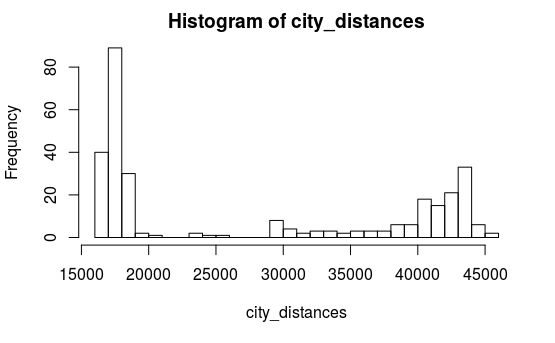

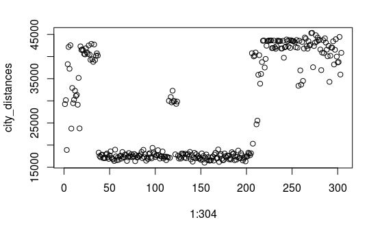

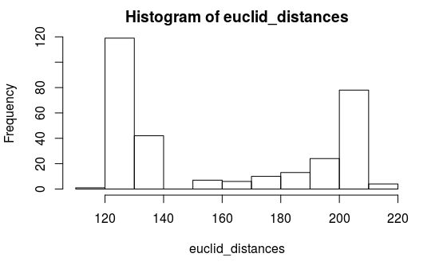

```r
hist(city_distances,breaks = 25)
plot(1:304,city_distances)

hist(euclid_distances)
```

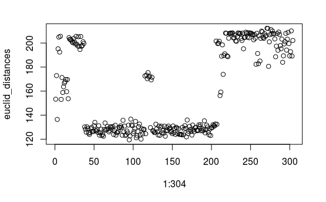

```r
plot(1:304,euclid_distances)
```

Now we have more than one kind of distance and set of magnitudes. Let’s set up a table of the different kinds of tables:

```r
norm(b-a,"1")
```

```
[1] 19257
```

```r
m=matrix(nrow=3,ncol=2)
m[1,]<-c(1,2)
m[2,]<-c(1,3)
m[3,]<-c(0,1)
n=matrix(nrow=3,ncol=2)
n[1,]<-c(1,4)
n[2,]<-c(2,0)
n[3,]<-c(0,-1)
print((m-n)[1:2,])
```

```
     [,1] [,2]
[1,]    0   -2
[2,]   -1    3
```

```r
sum(abs(m-n))
```

```
[1] 8
```

```r
5%%2
```

```
[1] 1
```

The following creates a distance table for hamming distance:

```r
for(i in 1:304){
  for(j in i:304){
    hd_matrix[i,j] <- hamming(gt_file[,i+1],gt_file[,j+1])
    hd_matrix[j,i] <- hd_matrix[i,j]
  }
  if (i%%20 == 0) print(i)
}
```

```
[1] 20
[1] 40
[1] 60
[1] 80
[1] 100
[1] 120
[1] 140
[1] 160
[1] 180
[1] 200
[1] 220
[1] 240
[1] 260
[1] 280
[1] 300
```

```r
clusters
```

```
  [1]   1   2   3   4   5   6   7   8   9  10  11  12  13  14  15  16  17  18  19  20  21  22  23
 [24]  24  25  26  27  28  29  30  31  32  33  34  35  36  37  38  39  40  41  42  43  44  45  46
 [47]  47  48  49  50  51  52  53  54  55  56  57  58  59  60  61  62  63  64  65  66  67  68  69
 [70]  70  71  72  73  74  75  76  77  78  79  80  81  82  83  84  85  86  87  88  89  90  91  92
 [93]  93  94  95  96  97  98  99 100 101 102 103 104 105 106 107 108 109 110 111 112 113 114 115
[116] 116 117 118 119 120 121 122 123 124 125 126 127 128 129 130 131 132 133 134 135 136 137 138
[139] 139 140 141 142 143 144 145 146 147 148 149 150 151 152 153 154 155 156 157 158 159 160 161
[162] 162 163 164 165 166 167 168 169 170 171 172 173 174 175 176 177 178 179 180 181 182 183 184
[185] 185 186 187 188 189 190 191 192 193 194 195 196 197 198 199 200 201 202 203 204 205 206 207
[208] 208 209 210 211 212 213 214 215 216 217 218 219 220 221 222 223 224 225 226 227 228 229 230
[231] 231 232 233 234 235 236 237 238 239 240 241 242 243 244 245 246 247 248 249 250 251 252 253
[254] 254 255 256 257 258 259 260 261 262 263 264 265 266 267 268 269 270 271 272 273 274 275 276
[277] 277 278 279 280 281 282 283 284 285 286 287 288 289 290 291 292 293 294 295 296 297 298 299
[300] 300 301 302 303 304
```

```r
png("Hamming_clusters.png",width=1800,height = 400)
plot(cl_tree,main='Hamming Distance Clusters',hang=-1)
dev.off()
```

We do the same for Cityblock distances.

```r
ct_tree1 <-hclust(dist(cd_matrix,method = "manhattan")) %>%
  as.dendrogram() %>%
  set("labels_cex", 0.5) %>%
  set("labels_col",value = 1:4,k=8) %>%
  set("branches_k_color", value = 1:4, k = 8) %>%
  set("branches_lty", c(1,1,3,1,1,2)) %>%
  set("labels",colnames(vcf_gt_match))
```

```
Length of color vector was shorter than the number of clusters - color vector was recycledThe lengths of the new labels is shorter than the number of leaves in the dendrogram - labels are recycled.
```

```
Length of color vector was shorter than the number of clusters - color vector was recycledThe lengths of the new labels is shorter than the number of leaves in the dendrogram - labels are recycled.
```

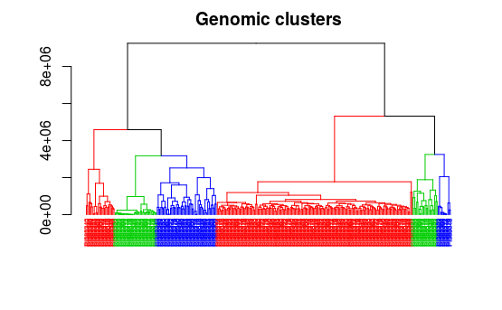

```r
ct_tree1 <-hclust(dist(cd_matrix,method = "manhattan")) %>%
  as.dendrogram() %>%
  set("labels_cex", 0.5) %>%
  set("labels_col",value = 2:4,k=6) %>%
  set("branches_k_color", value = 2:4, k = 6) %>%
  set("labels",colnames(vcf_gt_match)) %>%
  plot(main='Genomic clusters')
```

Now, put them together

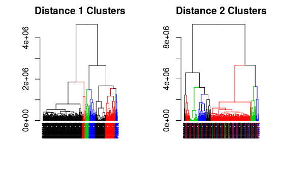

[output not shown]

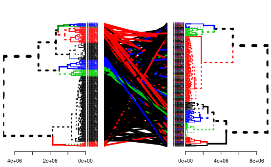

```r
trees=dendlist(ct_tree1,ct_tree2) %>%
untangle(method = "step1side") %>%
tanglegram(common_subtrees_color_branches = TRUE)
```

```r
length(labels_col(ct_tree1)[labels_col(ct_tree1)==labels_col(ct_tree2)])
```

```
[1] 155
```

```r
dend15 <- c(1:5) %>% dist %>% hclust(method = "average") %>% as.dendrogram
dend15 <- dend15 %>% set("labels_to_char")
dend51 <- dend15 %>% set("labels", as.character(5:1)) %>% match_order_by_labels(dend15)
dends_15_51 <- dendlist(dend15, dend51)
dends_15_51
```

```
[[1]]
'dendrogram' with 2 branches and 5 members total, at height 2.5

[[2]]
'dendrogram' with 2 branches and 5 members total, at height 2.5

attr(,"class")
[1] "dendlist"
```